# DDS-Analytics Presentation on Case Study for Employee Attrition at Frito Lay

Presented by: Seemant Srivastava

Date: December 5, 2019

##### Please visit my following links for detailed presentation and documentation of my Case study on Employee Attrition:-

##### YouTube video link: https://youtu.be/i5hs0tR_zCo

##### GitHub website link: https://seemantofbit.github.io/

##### RShiny App link: https://seemantsrivastava.shinyapps.io/Attrition/

##### GitHub repository link: https://github.com/seemantofbit/CaseStudy2DDS

## Good Afternoon, Mr. CEO and Mr. CFO of Frito Lay,

### Introduction:

#### As a consultant for the DDSAnalytics I have completed the analysis of the dataset on employee attrition that you have provided to me. I have found some interesting insights that will prove to assist your HR team on the talent management.

#### I have been provided with the employee attrition data and build a model to predict the attrition. The data you provided me on Employee Attrition contains information about 870 past employees who attrit from your company or were retained. There are 36 features available in the dataset. Here are the answers to important insights and analysis made on the employee attrition dataset.

## Initial Analysis of the employee attrition dataset:

### Summary:

#### Dataset Structure: 870 observations (rows), 36 features (variables)

#### Missing Data: Luckily for us, there is no missing data, this will make it easier to work with the dataset.

#### Data Type: We only have two datatypes in this dataset: factors and integers

#### Label “Attrition” is the label in our dataset and we would like to find out why employees are leaving the organization!

#### Imbalanced dataset: 730 (84% of cases) employees did not leave the organization while 140 (16% of cases) did leave the organization making our dataset to be considered imbalanced since more people stay in the organization than they actually leave.

```r
#check for NA values
table(is.na(employee))
```

```
##
## FALSE
## 31320
```

```r
# Checking the missing value
sapply(employee, function(x) sum(is.na(x)))
```

```
##                       ID                      Age                Attrition
##                        0                        0                        0
##           BusinessTravel                DailyRate               Department
##                        0                        0                        0
##         DistanceFromHome                Education           EducationField
##                        0                        0                        0
##            EmployeeCount           EmployeeNumber  EnvironmentSatisfaction
##                        0                        0                        0
##                   Gender               HourlyRate           JobInvolvement
##                        0                        0                        0
##                 JobLevel                  JobRole          JobSatisfaction
##                        0                        0                        0
##            MaritalStatus            MonthlyIncome              MonthlyRate
##                        0                        0                        0
##       NumCompaniesWorked                   Over18                 OverTime
##                        0                        0                        0
##        PercentSalaryHike        PerformanceRating RelationshipSatisfaction
##                        0                        0                        0
##            StandardHours         StockOptionLevel        TotalWorkingYears
##                        0                        0                        0
##    TrainingTimesLastYear          WorkLifeBalance           YearsAtCompany
##                        0                        0                        0
##       YearsInCurrentRole  YearsSinceLastPromotion     YearsWithCurrManager
##                        0                        0                        0
```

```r
#check for duplicated values
sum(duplicated(employee))
```

```
## [1] 0
```

```r
#see data frame dimensions and column data types
str(employee)
```

```
## 'data.frame':    870 obs. of  36 variables:
##  $ ID                      : int  1 2 3 4 5 6 7 8 9 10 ...
##  $ Age                     : int  32 40 35 32 24 27 41 37 34 34 ...
##  $ Attrition               : Factor w/ 2 levels "No","Yes": 1 1 1 1 1 1 1 1 1 1 ...
##  $ BusinessTravel          : Factor w/ 3 levels "Non-Travel","Travel_Frequently",..: 3 3 2 3 2 2 3 3 3 2 ...
##  $ DailyRate               : int  117 1308 200 801 567 294 1283 309 1333 653 ...
##  $ Department              : Factor w/ 3 levels "Human Resources",..: 3 2 2 3 2 2 2 3 3 2 ...
##  $ DistanceFromHome        : int  13 14 18 1 2 10 5 10 10 10 ...
##  $ Education               : int  4 3 2 4 1 2 5 4 4 4 ...
##  $ EducationField          : Factor w/ 6 levels "Human Resources",..: 2 4 2 3 6 2 4 2 2 6 ...
##  $ EmployeeCount           : int  1 1 1 1 1 1 1 1 1 1 ...
##  $ EmployeeNumber          : int  859 1128 1412 2016 1646 733 1448 1105 1055 1597 ...
##  $ EnvironmentSatisfaction : int  2 3 3 3 1 4 2 4 3 4 ...
##  $ Gender                  : Factor w/ 2 levels "Female","Male": 2 2 2 1 1 2 2 1 1 2 ...
##  $ HourlyRate              : int  73 44 60 48 32 32 90 88 87 92 ...
```

[output cut: 22 more lines]

```r
# remove some variable whose value is not changing. So standard deviation of that variable is zero. So it is not Significant for analysis. Those variable are ID, Employee Count, Employee Number, Over18, StandardHours
employee <- employee[, -c(1,10,11,23,28)]
```

## EDA (Exploratory Data Analysis):

#### Before modelling, we need to find out the variables that could be important in predicting the outcome. Therefore we do some univariate and bivariate data analysis to discover insights and try to correlate the data.

#### Correlation Matrix Plot is used to predict correlation between numeric variables. Some of the highly correlated variables.

##### 1.) Age variable is correlated with TotalWorkingYears

##### 2.) TotalWorkingYears correlated with MonthlyIncome

##### 3.) YearsWithCurrManager also correlated with YearsAtCompany

##### 4.) YearsWithCurrManger correlated with YearsInCurrentRole

##### 5.) YearsInCurrentRole correlated with YearsAtCompany

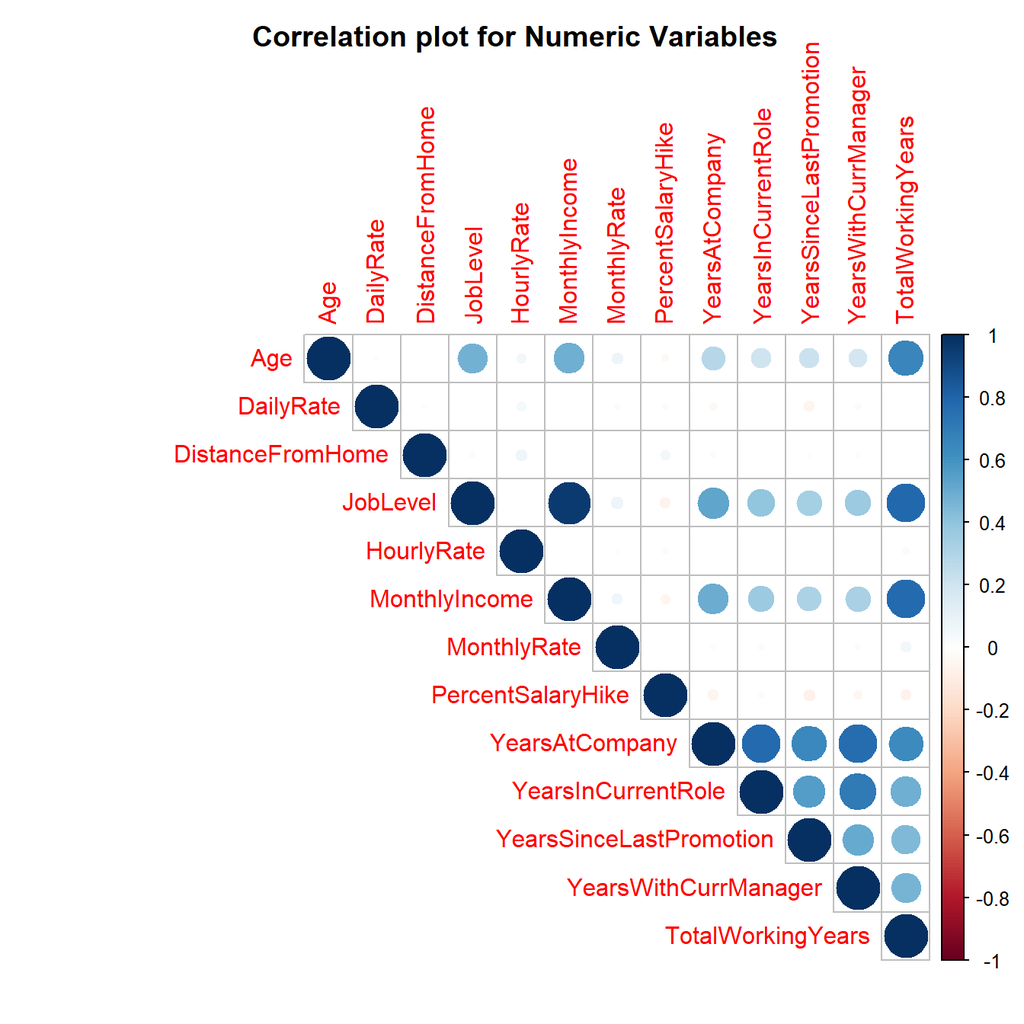

```r
# correlation between numeric variable
numeric=employee %>% dplyr::select(Age,DailyRate,DistanceFromHome,JobLevel,HourlyRate,MonthlyIncome,MonthlyRate,PercentSalaryHike,YearsAtCompany,YearsInCurrentRole,YearsSinceLastPromotion,YearsWithCurrManager,TotalWorkingYears)
corrplot(cor(numeric),main = '\n\n Correlation plot for Numeric Variables',method="circle",type="upper")
```

#### Number of employees who are leaving from the company:

##### The dataset is imbalanced with ~84% of the representation from no attrition and only ~16% is represented by attrition group.Therefore a baseline prediction would predict all the respondents as no attrition. Later on in the modeling section we will address the imbalanced data using the SMOTE technique.

```r
### let's see what percentage of people are leaving
employeeLeaving <- employee %>% group_by(Attrition) %>% summarise(n = n())
employeeLeaving
```

```
## # A tibble: 2 x 2
##   Attrition     n
##   <fct>     <int>
## 1 No          730
## 2 Yes         140
```

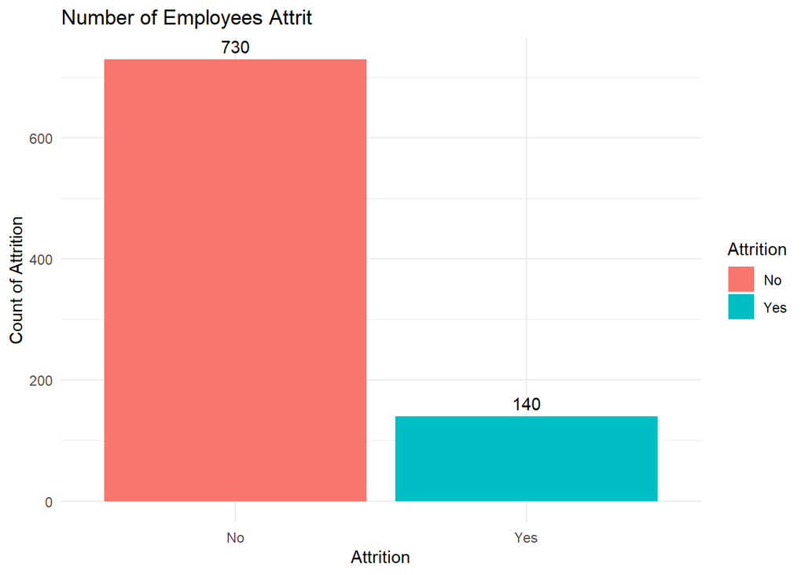

```r
employee %>% group_by(Attrition) %>% tally() %>% ggplot(aes(x = Attrition, y = n,fill=Attrition)) + geom_bar(stat = "identity") + theme_minimal()+ labs(x="Attrition", y="Count of Attrition")+ggtitle("Number of Employees Attrit")+
geom_text(aes(label = n), vjust = -0.5, position = position_dodge(0.9))
```

#### Income levels for the attrition employees:

##### The density plot clearly shows on a very high level that employees with lower monthly income of less than $5000 have higher attrition levels.

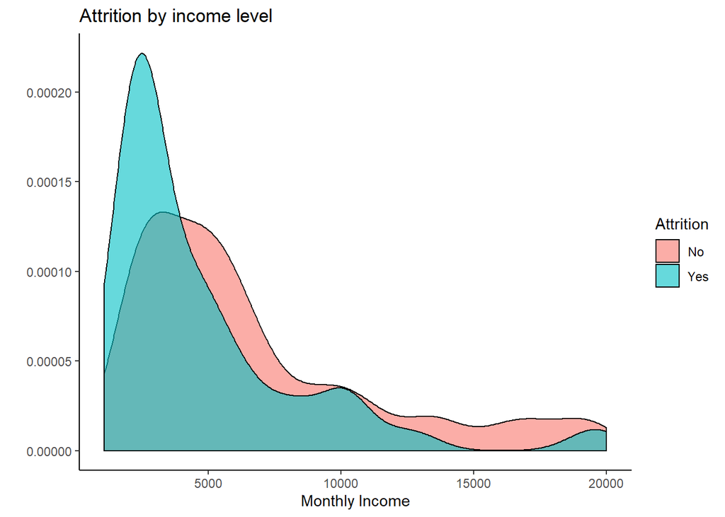

```r
# check income levels
ggplot(employee, aes(x = MonthlyIncome, fill = Attrition)) +
  geom_density(alpha = 0.6) +
  labs(x = "Monthly Income", y = "") +
  ggtitle("Attrition by income level") +
  theme_classic()
```

#### Attrition Vs Department:

##### Percentage of people who are leaving from their departments:

##### The amount of work and stress levels obviously depends on the department a person works in, this could be a good indicator of attrition levels.

```r
cat("There are",length(unique(employee$Department)),"unique departments in the dataset")
```

```
## There are 3 unique departments in the dataset
```

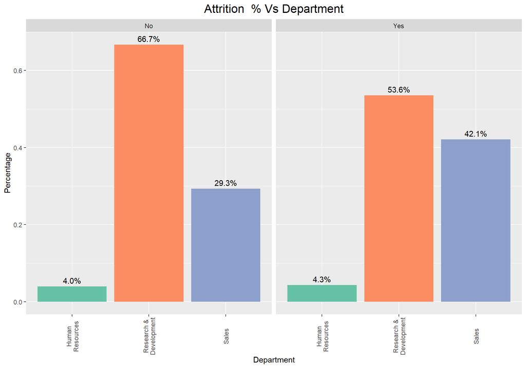

```r
ggplot(employee,aes(x=Department,group=Attrition))+geom_bar(aes(y=..prop..,fill=factor(..x..)),stat="count")+facet_grid(~Attrition)+theme(axis.text.x=element_text(angle=90,vjust=0.5),legend.position="none",plot.title=element_text(size=16,hjust=0.5))+labs(x="Department",y="Percentage",title="Attrition  % Vs Department")+ geom_text(aes(label = scales::percent(..prop..), y = ..prop.. ),stat= "count",vjust =-.5) +scale_x_discrete(labels=function(x) str_wrap(x,width=10))+scale_fill_brewer(palette="Set2")
```

#### Additional check for the attrition levels departmentwise:

##### Sales has seen higher attrition levels (about 21.6%) followed by HR(17.1%).

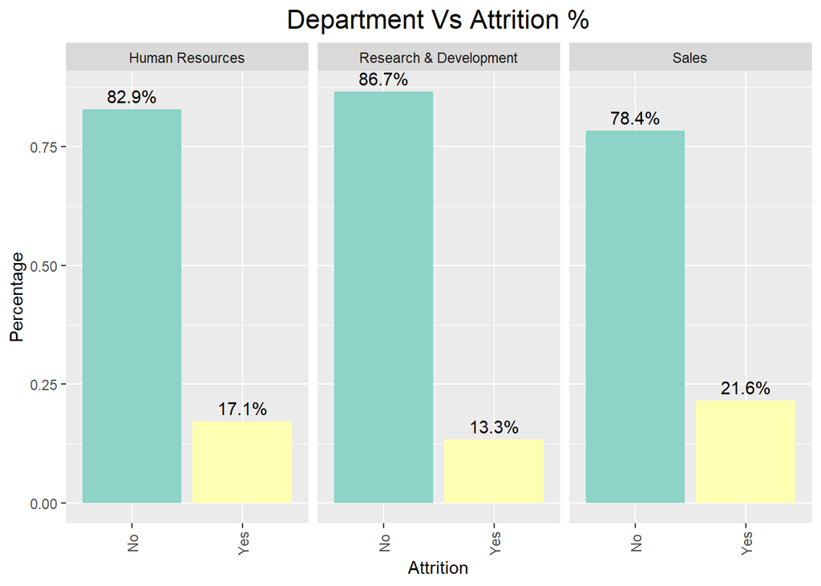

```r
ggplot(employee,aes(x=Attrition,group=Department))+geom_bar(aes(y=..prop..,fill=factor(..x..)),stat="count")+facet_grid(~Department)+theme(axis.text.x=element_text(angle=90,vjust=0.5),legend.position="none",plot.title=element_text(size=16,hjust=0.5))+labs(x="Attrition",y="Percentage",title="Department Vs Attrition %")+ geom_text(aes(label = scales::percent(..prop..), y = ..prop.. ),stat= "count",vjust =-.5) +scale_x_discrete(labels=function(x) str_wrap(x,width=10))+scale_fill_brewer(palette="Set3")
```

#### Attrition Vs Marital Status:

##### To check whether there is a relationship between attrition levels and marital status:

##### From the plot,it is understood that irrespective of the marital status,there are large people who stay with the company and do not leave.Therefore,marital status is a weak predictor of attrition.

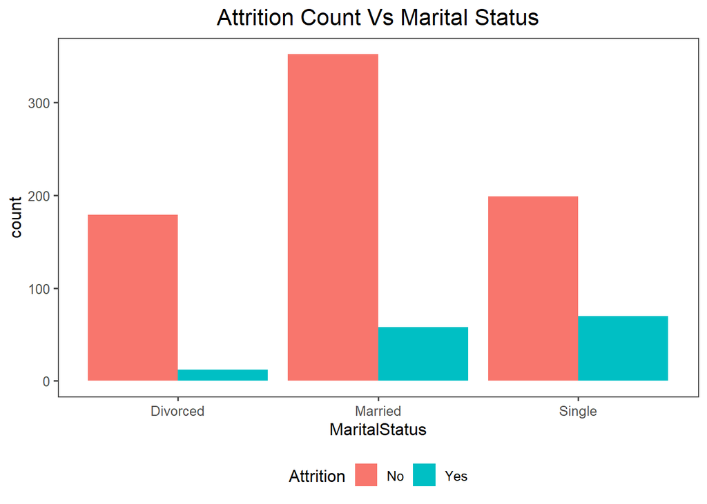

```r
## Attrition Vs Marital Status:
ggplot(employee,aes(MaritalStatus,..count..,fill=Attrition))+geom_bar(position=position_dodge())+theme_few()+theme(legend.position="bottom",plot.title=element_text(hjust=0.5,size=16))+labs(title="Attrition Count Vs Marital Status")
```

#### Attrition Vs Marital Status Vs age Vs monthly income:

#### Including age and monthly income and then doing the analysis for the attrition employees:

##### The trend is linear for age and monthly income across the marital status.

##### It is observed that attrition is more pronounced with “single” people across the age groups.

##### Married people having lower salary attrit more whereas divorced people have not attrited much.

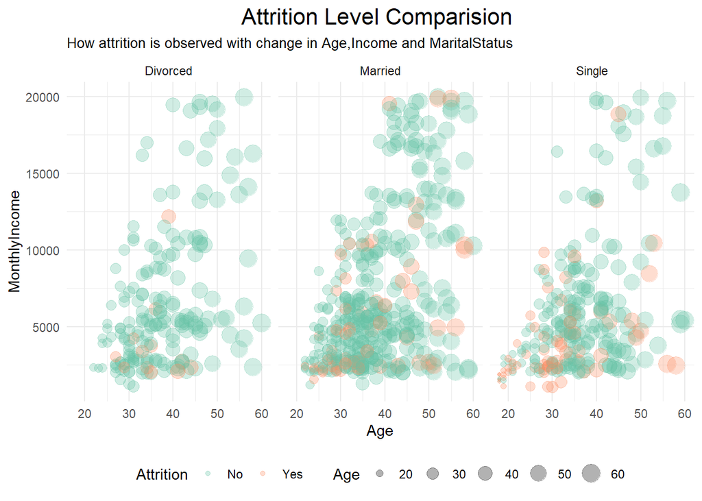

```r
# Attrition Vs Marital Status Vs age Vs monthly income
ggplot(employee,aes(Age,MonthlyIncome,size=Age,col=factor(Attrition)))+geom_point(alpha=0.3)+theme_minimal()+facet_wrap(~MaritalStatus)+labs(x="Age",y="MonthlyIncome",title="Attrition Level Comparision ",subtitle="How attrition is observed with change in Age,Income and MaritalStatus",col="Attrition")+theme(legend.position="bottom",plot.title=element_text(size=16,hjust=0.5),plot.subtitle = element_text(size=10))+scale_color_brewer(palette="Set2")
```

#### Attrition Vs Distance From Home:

##### There is a higher number of people who reside near to offices and hence the attrition levels are lower for distance <10 .With the increase in distance from home,the attrition curve overtakes the no attrition curve which is expected.

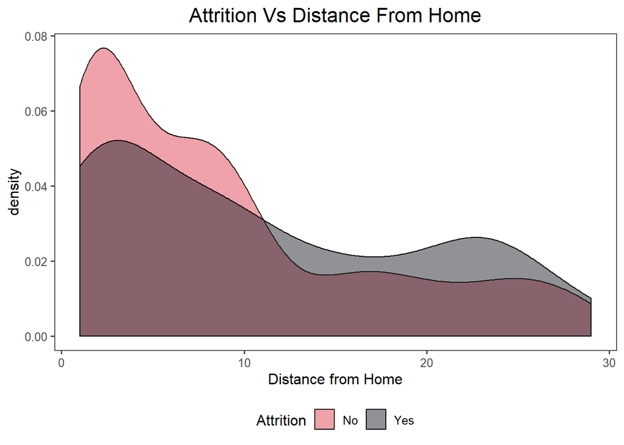

```r
ggplot(employee,aes(DistanceFromHome,fill=Attrition))+geom_density(alpha=0.5)+theme_few()+theme(legend.position="bottom",plot.title=element_text(hjust=0.5,size=16))+labs(x="Distance from Home",title="Attrition Vs Distance From Home")+scale_fill_canva(palette="Bold feature colors")
```

#### Attrition Vs Payrates:

##### It is wise to draw a boxplot to understand the monthly income and how it affects the attrition rate.We suspect that those who have been paid less will turnover.

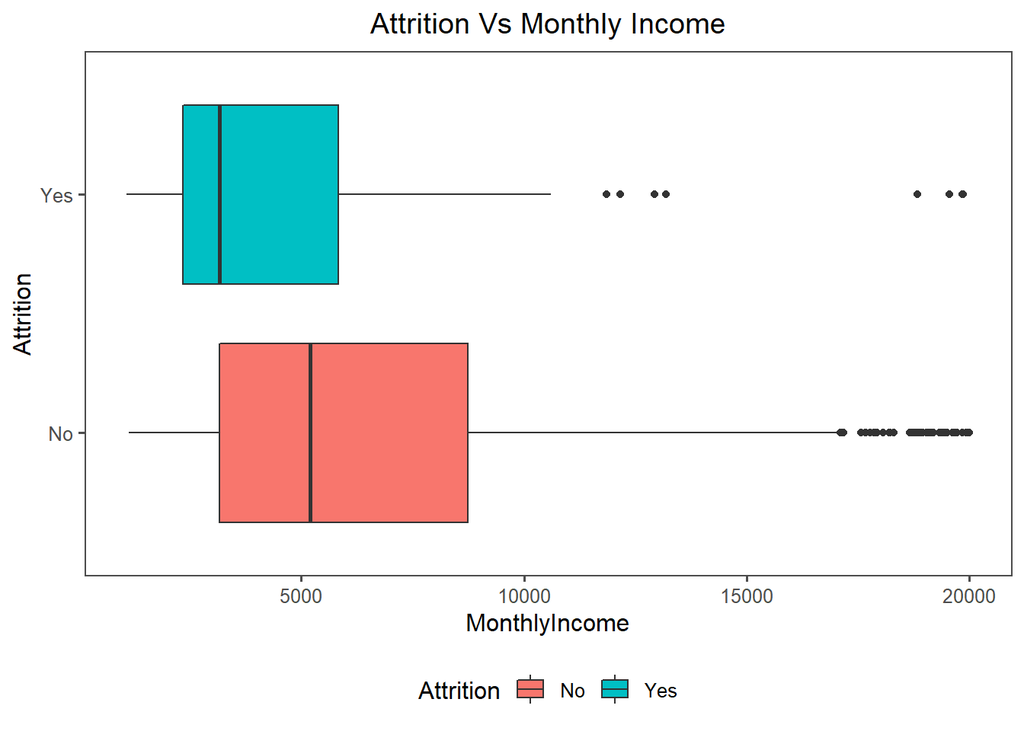

```r
ggplot(employee,aes(Attrition,MonthlyIncome,fill=Attrition))+geom_boxplot()+theme_few()+theme(plot.title=element_text(hjust=0.5),legend.position="bottom")+coord_flip()+labs(title="Attrition Vs Monthly Income")
```

#### Attrition Vs Education:

##### There are more people with a bachelors degree followed by masters degree.It is seen that the attrition levels are not pronounced across education levels, but the assumption is that people with higher education expect greater challenges to work on and if they dont find that this leads to lower satisfaction levels and consequently to attrition.

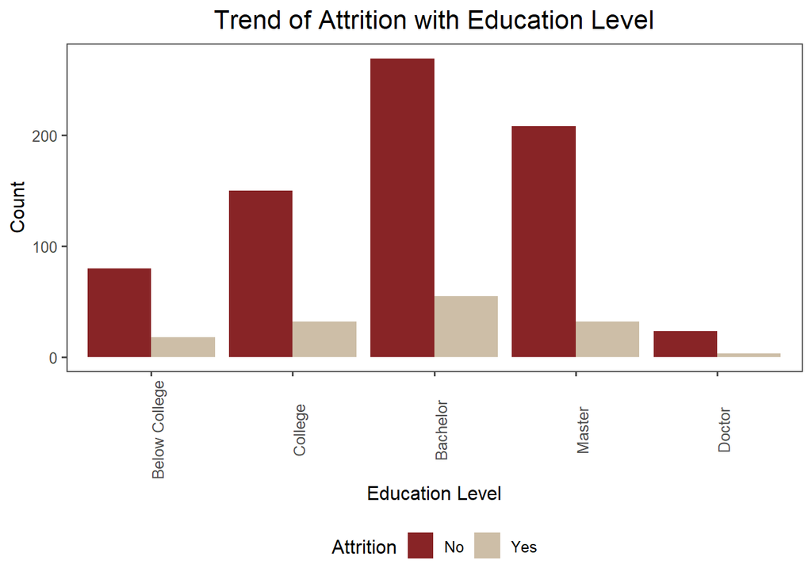

```r
temp = employee %>% mutate(Education=factor(Education)) %>% mutate(Education=fct_recode(Education,'Below College'='1','College'='2','Bachelor'='3','Master'='4','Doctor'='5'))
ggplot(temp,aes(Education,fill=Attrition))+geom_bar(stat="count",aes(y=..count..),position=position_dodge())+theme_few()+theme_few()+theme(legend.position="bottom",plot.title=element_text(hjust=0.5,size=16),axis.text.x = element_text(angle=90))+labs(x="Education Level",y="Count",title="Trend of Attrition with Education Level")+scale_fill_canva(palette="Golden afternoon")
```

#### Attrition Vs TotalWorkingYears:

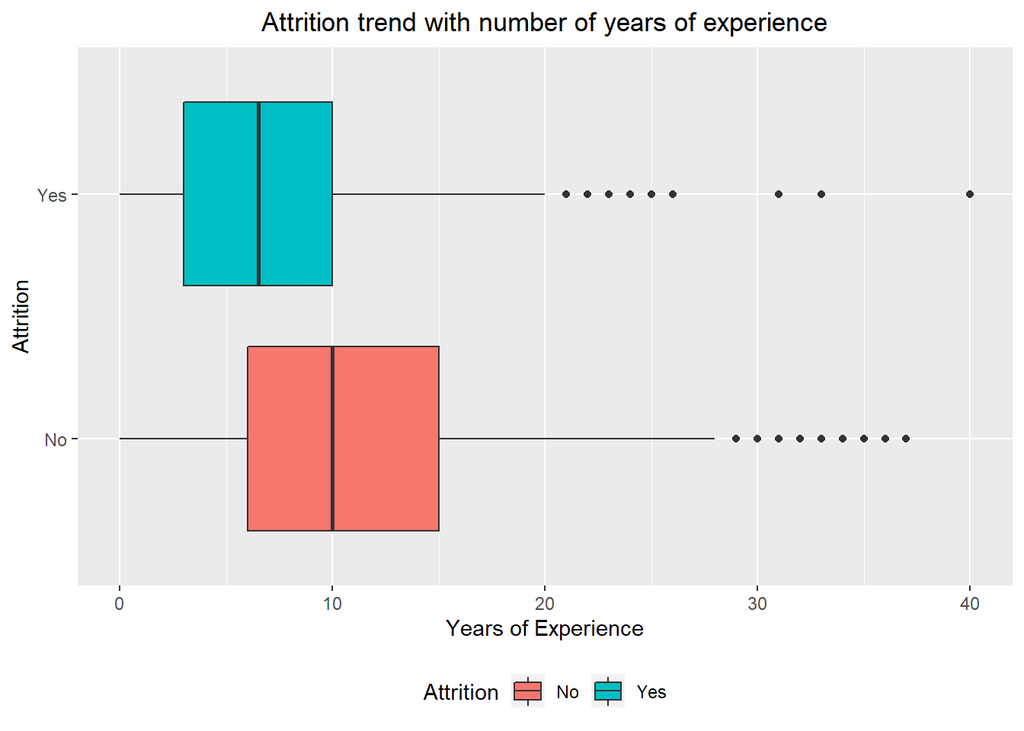

```r
ggplot(employee,aes(Attrition,TotalWorkingYears,fill=Attrition))+geom_boxplot()+theme(legend.position="bottom",plot.title=element_text(hjust=0.5))+labs(x="Attrition",y="Years of Experience",title="Attrition trend with number of years of experience")+coord_flip()
```

#### Attrition Vs Job Satisfaction:

##### As expected,people with low satisfaction have left the company (27.1%) in large number .What is surprising is ,out of those who leave about 30.7% have experience high job satisfaction.Therefore,there should be some other factor which triggers their exit from the present company.

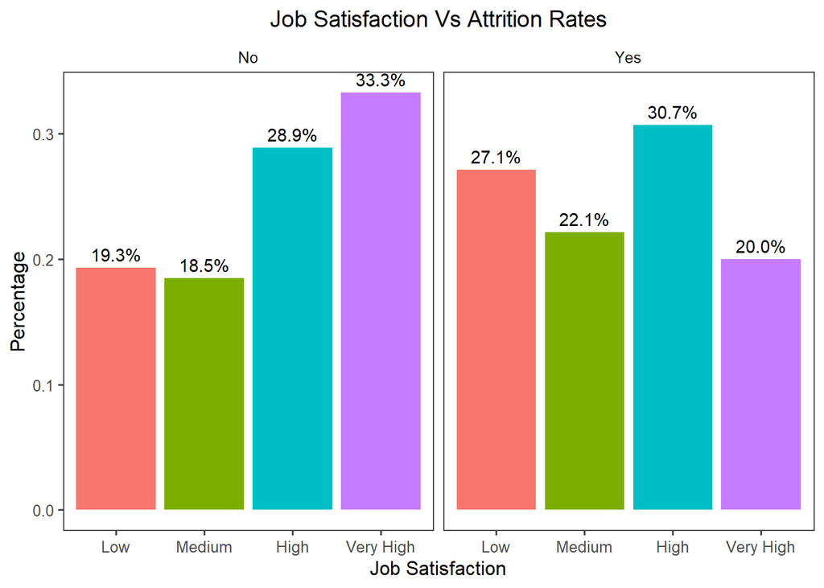

```r
temp = employee %>% mutate(JobSatisfaction=factor(JobSatisfaction)) %>% mutate(JobSatisfaction=fct_recode(JobSatisfaction,"Low"="1","Medium"="2","High"="3","Very High"="4"))
ggplot(temp,aes(x=JobSatisfaction,group=Attrition))+geom_bar(stat="count",aes(y=..prop..,fill=factor(..x..)))+labs(x="Job Satisfaction",y="Percentage",title="Job Satisfaction Vs Attrition Rates")+facet_wrap(~Attrition)+theme_few()+theme(legend.position="none",plot.title=element_text(hjust=0.5,size=14))+geom_text(aes(label=scales::percent(..prop..),y=..prop..),stat="count",vjust=-0.5)
```

#### Attrition Vs Worklife balance:

##### As seen with the other categorical variables,here too we find that people having better work life balance leave the company whereas about 61.9% who have experienced better work life balance stay with the company.We now continue with our last categorical variable-Environment satisfaction.

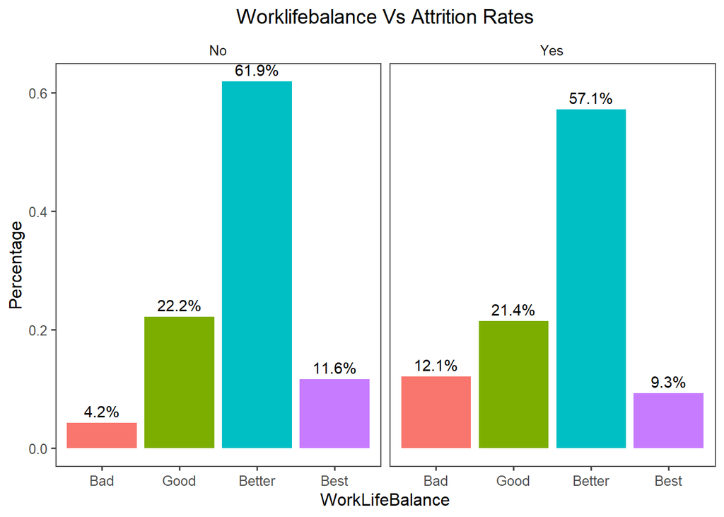

```r
temp= employee %>% mutate(WorkLifeBalance=factor(WorkLifeBalance)) %>% mutate(WorkLifeBalance=fct_recode(WorkLifeBalance,"Bad"="1","Good"="2","Better"="3","Best"="4"))
ggplot(temp,aes(x=WorkLifeBalance,group=Attrition))+geom_bar(stat="count",aes(y=..prop..,fill=factor(..x..)))+labs(x="WorkLifeBalance",y="Percentage",title="Worklifebalance Vs Attrition Rates")+facet_wrap(~Attrition)+theme_few()+theme(legend.position="none",plot.title=element_text(hjust=0.5,size=14))+geom_text(aes(label=scales::percent(..prop..),y=..prop..),stat="count",vjust=-0.5)
```

#### Attrition Vs Environment Satisfaction:

##### Here we see that people having low environment satisfaction (30%) leave the company.

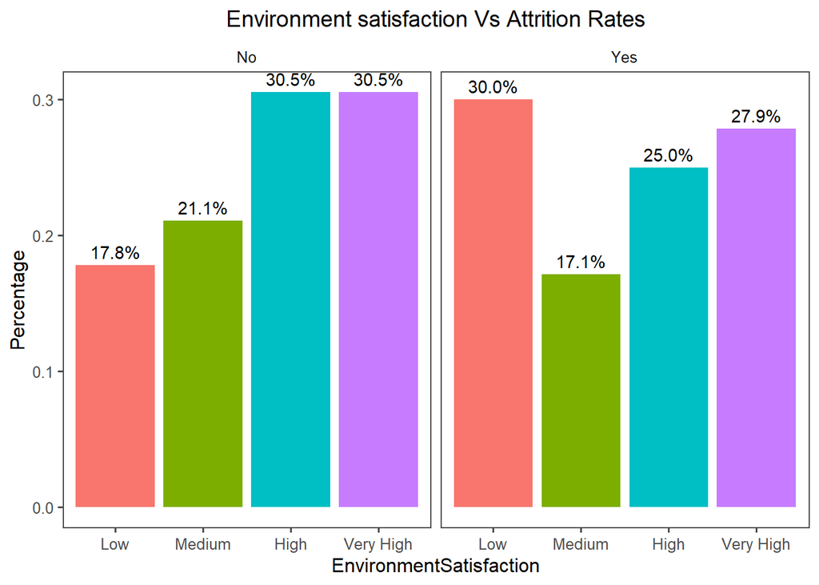

```r
temp= employee %>% mutate(EnvironmentSatisfaction=factor(EnvironmentSatisfaction)) %>% mutate(EnvironmentSatisfaction=fct_recode(EnvironmentSatisfaction,"Low"="1","Medium"="2","High"="3","Very High"="4"))
ggplot(temp,aes(x=EnvironmentSatisfaction,group=Attrition))+geom_bar(stat="count",aes(y=..prop..,fill=factor(..x..)))+labs(x="EnvironmentSatisfaction",y="Percentage",title="Environment satisfaction Vs Attrition Rates")+facet_wrap(~Attrition)+theme_few()+theme(legend.position="none",plot.title=element_text(hjust=0.5,size=14))+geom_text(aes(label=scales::percent(..prop..),y=..prop..),stat="count",vjust=-0.5)
```

#### Attrition Vs OverTime:

##### 57.1% of those who experience attrition have worked overtime whereas 76.4% of those who have not experienced overtime have not left the company.Therefore overtime is a strong indicator of attrition.

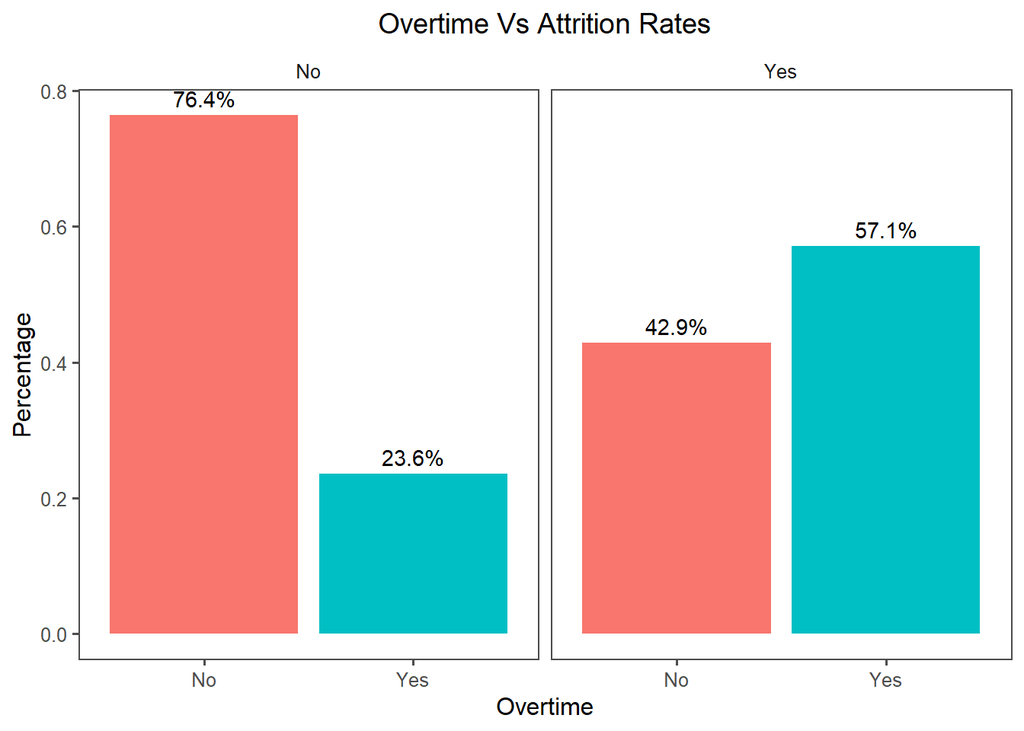

```r
ggplot(employee,aes(x=OverTime,group=Attrition))+geom_bar(stat="count",aes(y=..prop..,fill=factor(..x..)))+labs(x="Overtime",y="Percentage",title="Overtime Vs Attrition Rates")+facet_wrap(~Attrition)+theme_few()+theme(legend.position="none",plot.title=element_text(hjust=0.5,size=14))+geom_text(aes(label=scales::percent(..prop..),y=..prop..),stat="count",vjust=-0.5)
```

#### Attrition for years of experience vs monthly salary and their correlation:

##### As expected,there exists a linear relationship between years of experience and monthly income as shown by the line.

##### There is a point in the graph,where the lines seems to intersect after which the no attrition line has higher monthly income compared to yes attrition line.

##### If a person stays in the company then how long he stays in the current role and there is a linear relation between the two predictors.

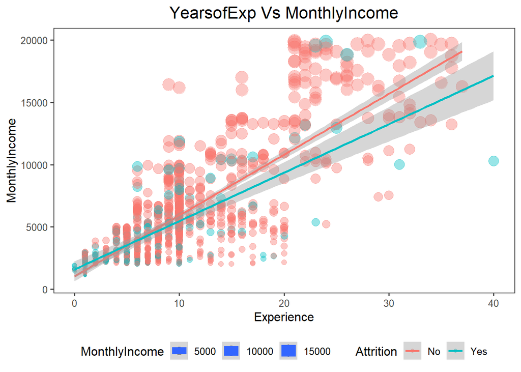

```r
ggplot(employee,aes(TotalWorkingYears,MonthlyIncome,size=MonthlyIncome,col=factor(Attrition)))+geom_point(alpha=0.4)+theme_few()+theme(plot.title=element_text(hjust=0.5,size=16),legend.position="bottom")+labs(x="Experience",y="MonthlyIncome",title="YearsofExp Vs MonthlyIncome",col="Attrition")+geom_smooth(method="lm")
```

## Feature Selection:

#### Checking Multicollinearity (VIF)

##### vif(variation inflation factor) function uses to predict the vif value. If vif value is greater than 10 then regression co-efficient are poorly estimated due to multicollinearity and if the vif value lies between 2 - 10 then it is highly correlated.

```r
# data preparation for modeling
employee2 <- employee
# Changing the class of variable from numeric to factor
employee2$Education <- factor(employee2$Education)
employee2$EnvironmentSatisfaction <- factor(employee2$EnvironmentSatisfaction)
employee2$JobInvolvement <- factor(employee2$JobInvolvement)
employee2$JobLevel <- factor(employee2$JobLevel)
employee2$JobSatisfaction <- factor(employee2$JobSatisfaction)
employee2$PerformanceRating <- factor(employee2$PerformanceRating)
employee2$RelationshipSatisfaction <- factor(employee2$RelationshipSatisfaction)
employee2$StockOptionLevel <- factor(employee2$StockOptionLevel)
employee2$WorkLifeBalance <- factor(employee2$WorkLifeBalance)
# Changing the Atrition variable value to 1 for 'Yes' and 0 for 'No'
employee2$Attrition <- ifelse(employee2$Attrition == "Yes",1,0)

# Changing the categorical variables to dummy variable so that the variables can be used for fit in the model
dmy <- dummyVars(" ~ .", data = employee2, fullRank=T)
employee3 <- data.frame(predict(dmy, newdata = employee2))
print(str(employee3))
```

```
## 'data.frame':    870 obs. of  63 variables:
##  $ Age                              : num  32 40 35 32 24 27 41 37 34 34 ...
##  $ Attrition                        : num  0 0 0 0 0 0 0 0 0 0 ...
##  $ BusinessTravel.Travel_Frequently : num  0 0 1 0 1 1 0 0 0 1 ...
##  $ BusinessTravel.Travel_Rarely     : num  1 1 0 1 0 0 1 1 1 0 ...
##  $ DailyRate                        : num  117 1308 200 801 567 ...
##  $ Department.Research...Development: num  0 1 1 0 1 1 1 0 0 1 ...
##  $ Department.Sales                 : num  1 0 0 1 0 0 0 1 1 0 ...
##  $ DistanceFromHome                 : num  13 14 18 1 2 10 5 10 10 10 ...
##  $ Education.2                      : num  0 0 1 0 0 1 0 0 0 0 ...
##  $ Education.3                      : num  0 1 0 0 0 0 0 0 0 0 ...
##  $ Education.4                      : num  1 0 0 1 0 0 0 1 1 1 ...
##  $ Education.5                      : num  0 0 0 0 0 0 1 0 0 0 ...
##  $ EducationField.Life.Sciences     : num  1 0 1 0 0 1 0 1 1 0 ...
##  $ EducationField.Marketing         : num  0 0 0 1 0 0 0 0 0 0 ...
```

[output cut: 50 more lines]

```r
# VIF check for Multicollinearity
vif_output <- lm(Attrition ~., data = employee3)
vif_res <- car::vif(vif_output)
summary(vif_res)
```

```
##    Min. 1st Qu.  Median    Mean 3rd Qu.    Max.
##   1.062   1.834   2.869   5.961   5.338  41.996
```

```r
print(vif_res)
```

```
##                               Age  BusinessTravel.Travel_Frequently
##                          2.032099                          2.349610
##      BusinessTravel.Travel_Rarely                         DailyRate
##                          2.371303                          1.072145
## Department.Research...Development                  Department.Sales
##                         41.928691                         41.995785
##                  DistanceFromHome                       Education.2
##                          1.091408                          2.442393
##                       Education.3                       Education.4
##                          2.913224                          2.900765
##                       Education.5      EducationField.Life.Sciences
##                          1.374303                         26.023089
##          EducationField.Marketing            EducationField.Medical
##                         12.345064                         23.065974
##              EducationField.Other   EducationField.Technical.Degree
##                          6.950375                          9.191336
##         EnvironmentSatisfaction.2         EnvironmentSatisfaction.3
##                          1.707615                          1.881001
##         EnvironmentSatisfaction.4                       Gender.Male
##                          1.876365                          1.064385
##                        HourlyRate                  JobInvolvement.2
##                          1.066661                          4.544043
##                  JobInvolvement.3                  JobInvolvement.4
##                          5.225714                          2.637391
##                        JobLevel.2                        JobLevel.3
##                          4.991545                          7.630939
##                        JobLevel.4                        JobLevel.5
##                          9.541048                          9.407292
##           JobRole.Human.Resources     JobRole.Laboratory.Technician
##                          6.511811                          4.300969
##                   JobRole.Manager    JobRole.Manufacturing.Director
##                          4.705541                          2.076369
##         JobRole.Research.Director        JobRole.Research.Scientist
##                          3.086920                          4.753584
##           JobRole.Sales.Executive      JobRole.Sales.Representative
##                         18.230633                          7.492536
##                 JobSatisfaction.2                 JobSatisfaction.3
##                          1.664792                          1.814517
##                 JobSatisfaction.4             MaritalStatus.Married
##                          1.832010                          1.991775
##              MaritalStatus.Single                     MonthlyIncome
##                          4.211170                         22.327073
##                       MonthlyRate                NumCompaniesWorked
##                          1.081048                          1.413734
##                      OverTime.Yes                 PercentSalaryHike
##                          1.061952                          2.700371
##               PerformanceRating.4        RelationshipSatisfaction.2
##                          2.680772                          1.708293
##        RelationshipSatisfaction.3        RelationshipSatisfaction.4
##                          1.871441                          1.838717
##                StockOptionLevel.1                StockOptionLevel.2
##                          2.863025                          1.813770
##                StockOptionLevel.3                 TotalWorkingYears
##                          1.634511                          5.865167
##             TrainingTimesLastYear                 WorkLifeBalance.2
##                          1.078947                          4.133261
##                 WorkLifeBalance.3                 WorkLifeBalance.4
##                          5.028300                          2.875647
##                    YearsAtCompany                YearsInCurrentRole
##                          5.375685                          3.092657
##           YearsSinceLastPromotion              YearsWithCurrManager
##                          1.927687                          2.895128
```

## Modelling:

### Logistic Regression model for classification of employees into Attrition or no Attrition:

```r
## Logistic Regression model

#Split data into train and test using cross validation in ratio of 70% train and 30% test
set.seed(2017)
train <- sample(1:nrow(employee3), nrow(employee3)*.7)
test = -train
modeldata <- employee3[train,]
validationdata <- employee3[test,]
cat("Train data has", nrow(modeldata),"observations")
```

```
## Train data has 609 observations
```

```r
cat("Test data has", nrow(validationdata),"observations")
```

```
## Test data has 261 observations
```

```r
# Fitting the Logistic Regression Model
logmodel <- glm(Attrition ~., family=binomial(link="logit"), data = modeldata)
print(summary(logmodel))
```

```
##
## Call:
## glm(formula = Attrition ~ ., family = binomial(link = "logit"),
##     data = modeldata)
##
## Deviance Residuals:
##     Min       1Q   Median       3Q      Max
## -1.7146  -0.3629  -0.1062  -0.0049   3.2962
##
## Coefficients:
##                                     Estimate Std. Error z value Pr(>|z|)
## (Intercept)                       -1.089e+01  4.361e+03  -0.002 0.998008
## Age                               -8.203e-02  2.845e-02  -2.883 0.003941
## BusinessTravel.Travel_Frequently   2.057e+00  7.320e-01   2.811 0.004943
## BusinessTravel.Travel_Rarely       5.808e-01  6.252e-01   0.929 0.352961
## DailyRate                         -5.741e-04  4.551e-04  -1.261 0.207192
## Department.Research...Development  1.879e+01  4.361e+03   0.004 0.996562
## Department.Sales                   1.892e+01  4.361e+03   0.004 0.996538
## DistanceFromHome                   8.258e-02  2.325e-02   3.552 0.000382
## Education.2                        8.404e-01  6.113e-01   1.375 0.169204
## Education.3                        3.318e-01  5.489e-01   0.605 0.545501
## Education.4                        1.388e-01  6.132e-01   0.226 0.820921
## Education.5                        2.488e+00  1.236e+00   2.013 0.044153
## EducationField.Life.Sciences      -1.218e+00  1.925e+00  -0.633 0.526981
## EducationField.Marketing          -1.648e+00  1.995e+00  -0.826 0.408565
## EducationField.Medical            -1.424e+00  1.929e+00  -0.738 0.460631
## EducationField.Other              -1.076e+00  2.030e+00  -0.530 0.596044
## EducationField.Technical.Degree   -8.578e-01  2.009e+00  -0.427 0.669456
## EnvironmentSatisfaction.2         -1.876e+00  5.583e-01  -3.360 0.000779
## EnvironmentSatisfaction.3         -1.463e+00  5.069e-01  -2.885 0.003911
## EnvironmentSatisfaction.4         -1.568e+00  5.256e-01  -2.983 0.002853
## Gender.Male                        1.218e-01  3.499e-01   0.348 0.727828
## HourlyRate                         1.030e-02  8.895e-03   1.158 0.246952
## JobInvolvement.2                  -2.107e+00  6.526e-01  -3.228 0.001244
## JobInvolvement.3                  -2.585e+00  6.158e-01  -4.198 2.70e-05
## JobInvolvement.4                  -2.653e+00  8.162e-01  -3.250 0.001152
## JobLevel.2                        -2.146e+00  9.957e-01  -2.155 0.031154
## JobLevel.3                         8.499e-01  1.488e+00   0.571 0.567743
## JobLevel.4                         5.465e-01  2.394e+00   0.228 0.819419
## JobLevel.5                         4.577e+00  3.095e+00   1.479 0.139093
```

[output cut: 93 more lines]

```
## WorkLifeBalance.4                 ***
## YearsAtCompany                    **
## YearsInCurrentRole
## YearsSinceLastPromotion           *
## YearsWithCurrManager              ***
## ---
## Signif. codes:  0 '***' 0.001 '**' 0.01 '*' 0.05 '.' 0.1 ' ' 1
##
## (Dispersion parameter for binomial family taken to be 1)
##
##     Null deviance: 556.76  on 608  degrees of freedom
## Residual deviance: 265.40  on 546  degrees of freedom
## AIC: 391.4
##
## Number of Fisher Scoring iterations: 18
```

```r
# Accessing the predictive ability of the logistic regression model
log_pred <- predict(logmodel,newdata=validationdata,type='response')
log_pred <- ifelse(log_pred>=0.5,1,0)
confusionMatrix(factor(log_pred),factor(validationdata$Attrition))
```

```
## Confusion Matrix and Statistics
##
##           Reference
## Prediction   0   1
##          0 211  14
##          1  14  22
##
##                Accuracy : 0.8927
##                  95% CI : (0.8487, 0.9275)
##     No Information Rate : 0.8621
##     P-Value [Acc > NIR] : 0.08585
##
##                   Kappa : 0.5489
##
##  Mcnemar's Test P-Value : 1.00000
##
##             Sensitivity : 0.9378
##             Specificity : 0.6111
##          Pos Pred Value : 0.9378
##          Neg Pred Value : 0.6111
##              Prevalence : 0.8621
##          Detection Rate : 0.8084
##    Detection Prevalence : 0.8621
##       Balanced Accuracy : 0.7744
##
##        'Positive' Class : 0
##
```

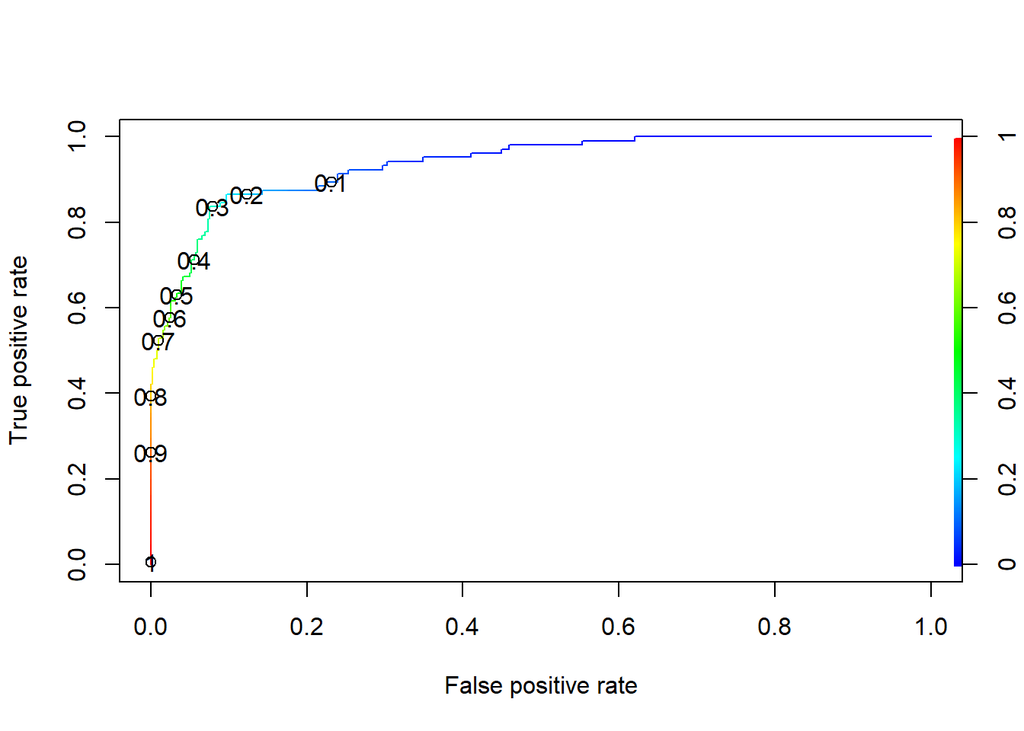

```r
# Plotting the ROC curve
res <- predict(logmodel, modeldata, type = "response")
ROCRPred <- prediction(res, modeldata$Attrition)
ROCRPerf <- performance(ROCRPred,"tpr","fpr")
plot(ROCRPerf,colorize = TRUE, print.cutoffs.at = seq(0.1, by = 0.1))
```

### Conclusion for the Logistic Regression model for classification of employees into Attrition or no Attrition:-

##### Accuracy - It is the ratio of total number of correct predictor based upon the total number of predictor. It explain about model predicting accuracy. The accuracy for the Logistic Regression model is 89%.

##### Sensitivity - The proportion of actual positive cases that were correctly identified.The sensitivity for the Logistic Regression model is 94%.

##### Specificity - The proportion of actual negative cases that were correctly identified.The specificity for the Logistic Regression model is 61%.

##### Based on the Logistic Regression model, the variable which majorly affect the attrition are:-

###### Highly Significant: are DistanceFromHome,EnvironmentSatisfaction (Low),JobInvolvement (High/Moderate),NumCompaniesWorked, OverTime (Yes),RelationshipSatisfaction (Low),WorkLifeBalance (Low),YearsWithCurrManager

###### Significant: Age,BusinessTravel (Frequently),JobSatisfaction (Low),

###### Moderately Significant: Education (Higher Education),MaritalStatus (Single),YearsSinceLastPromotion (High),StockOptionLevel(Less)

##### To conclude for the Logistic Regression model, the variable which majorly affect the attrition are OverTime (Yes), Business Travel, EnvironmentSatisfaction (Low), JobInvolvement (High/Moderate), NumCompaniesWorked, RelationshipSatisfaction (Low), WorkLifeBalance (Low), YearsWithCurrManager,StockOptionLevel(Low) etc.

### k-NN model for classification of employess into Attrition or no Attrition:

```r
## k-NN model having 70-30 train/test Cross Validation along with hyperparamater tuning
splitPerc = .7
iterations = 100
numks = 50
masterAccuracy = matrix(nrow = iterations, ncol = numks)
masterSensitivity = matrix(nrow = iterations, ncol = numks)
masterSpecificity = matrix(nrow = iterations, ncol = numks)
for(j in 1:iterations)
{
set.seed(j)
train <- sample(1:nrow(employee3), nrow(employee3)*splitPerc)
test = -train
modeldata <- employee3[train,]
validationdata <- employee3[test,]
for(i in 1:numks)
{
classifications = knn(modeldata[,-2], validationdata[,-2], modeldata$Attrition, prob = TRUE, k = i)
table(classifications,validationdata$Attrition)
CM = confusionMatrix(table(classifications,validationdata$Attrition))
masterAccuracy[j,i] = CM$overall[1]    #Accuracy
masterSensitivity[j,i] = CM$byClass[1] #Sensitivity
masterSpecificity[j,i] = CM$byClass[2] #Specificity
}
}
MeanAccuracy = colMeans(masterAccuracy)
which.max(MeanAccuracy)
```

```
## [1] 21
```

```r
max(MeanAccuracy)
```

```
## [1] 0.84
```

```r
mean(MeanAccuracy) #average KNN accuracy
```

```
## [1] 0.832767
```

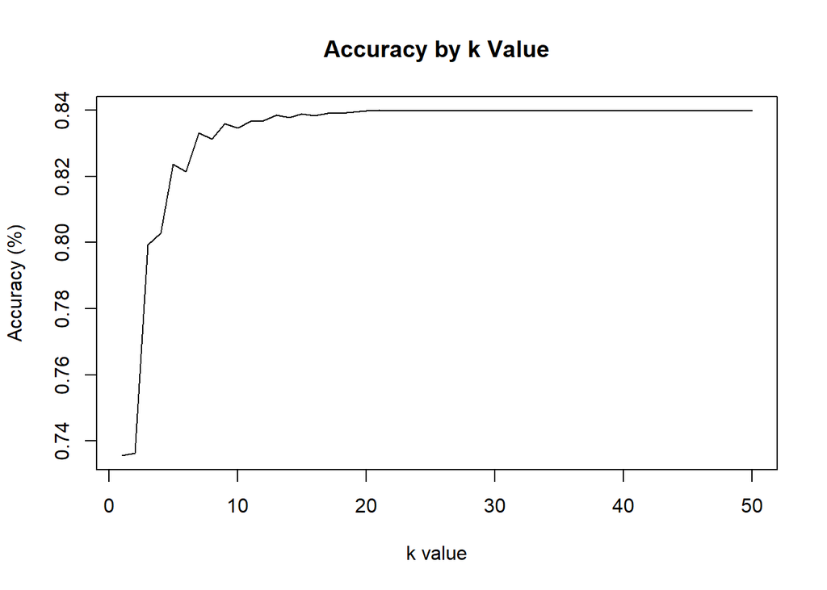

```r
plot(seq(1,numks,1),MeanAccuracy, type = "l", xlab = "k value", ylab = "Accuracy (%)", main ="Accuracy by k Value")
```

```r
MeanSpecificity = colMeans(masterSensitivity)
which.max(MeanSpecificity)
```

```
## [1] 21
```

```r
max(MeanSpecificity)
```

```
## [1] 1
```

```r
mean(MeanSpecificity) #average KNN specificity
```

```
## [1] 0.9878007
```

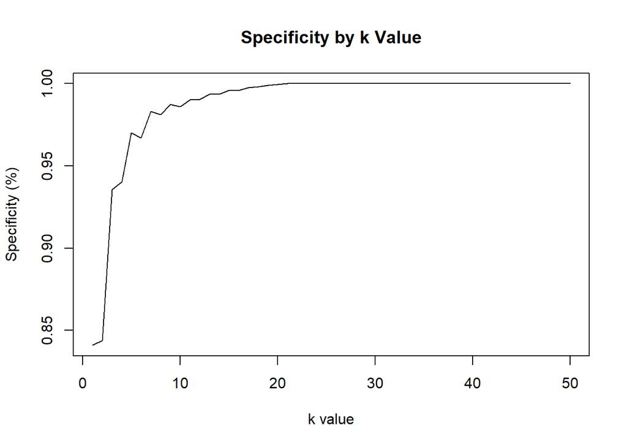

```r
plot(seq(1,numks,1),MeanSpecificity, type = "l", xlab = "k value", ylab = "Specificity (%)", main ="Specificity by k Value")
```

```r
## k-NN model for k=2
#Split data into train and test using cross validation in ratio of 70% train and 30% test
set.seed(1)
train <- sample(1:nrow(employee3), nrow(employee3)*.7)
test = -train
modeldata <- employee3[train,]
validationdata <- employee3[test,]
cat("Train data has", nrow(modeldata),"observations")
```

```
## Train data has 609 observations
```

```r
cat("Test data has", nrow(validationdata),"observations")
```

```
## Test data has 261 observations
```

```r
# k-NN classification
classifications = knn(modeldata[,-2], validationdata[,-2], modeldata$Attrition, prob = TRUE, k = 2)
table(classifications,validationdata$Attrition)
```

```
##
## classifications   0   1
##               0 181  38
##               1  34   8
```

```r
CM = confusionMatrix(table(classifications,validationdata$Attrition))
CM
```

```
## Confusion Matrix and Statistics
##
##
## classifications   0   1
##               0 181  38
##               1  34   8
##
##                Accuracy : 0.7241
##                  95% CI : (0.6657, 0.7775)
##     No Information Rate : 0.8238
##     P-Value [Acc > NIR] : 1.0000
##
##                   Kappa : 0.0163
##
##  Mcnemar's Test P-Value : 0.7237
##
##             Sensitivity : 0.8419
##             Specificity : 0.1739
##          Pos Pred Value : 0.8265
##          Neg Pred Value : 0.1905
##              Prevalence : 0.8238
##          Detection Rate : 0.6935
##    Detection Prevalence : 0.8391
##       Balanced Accuracy : 0.5079
##
##        'Positive' Class : 0
##
```

```r
## k-NN model - Leave One Out k-NN or Internal CV k-NN
classifications = knn.cv(employee3[,-2], employee3$Attrition, prob = TRUE, k = 2)
confusionMatrix(table(classifications,employee3$Attrition))
```

```
## Confusion Matrix and Statistics
##
##
## classifications   0   1
##               0 605 116
##               1 125  24
##
##                Accuracy : 0.723
##                  95% CI : (0.692, 0.7525)
##     No Information Rate : 0.8391
##     P-Value [Acc > NIR] : 1.0000
##
##                   Kappa : 2e-04
##
##  Mcnemar's Test P-Value : 0.6063
##
##             Sensitivity : 0.8288
##             Specificity : 0.1714
##          Pos Pred Value : 0.8391
##          Neg Pred Value : 0.1611
##              Prevalence : 0.8391
##          Detection Rate : 0.6954
##    Detection Prevalence : 0.8287
##       Balanced Accuracy : 0.5001
##
##        'Positive' Class : 0
##
```

### Conclusion for the k-NN model (best k-NN model which is the full model using all the predictor variables) for classification of employees into Attrition or no Attrition:-

##### Accuracy - It is the ratio of total number of correct predictor based upon the total number of predictor. It explain about model predicting accuracy. The accuracy for the k-NN model is 72%.

##### Sensitivity - The proportion of actual positive cases that were correctly identified.The sensitivity for the k-NN model is 84%.

##### Specificity - The proportion of actual negative cases that were correctly identified.The specificity for the k-NN model is 17%.

##### To conclude for the k-NN model, the specificty for the model is not so good, as the dataset is imbalanced which will bias the prediction model towards the more common class (here is ‘NO’). From this k-NN model, there is also not much conclusive variable importance which majorly affects the attrition.

### Solving Unbalanced data problem using SMOTE method, and then running the k-NN model:-

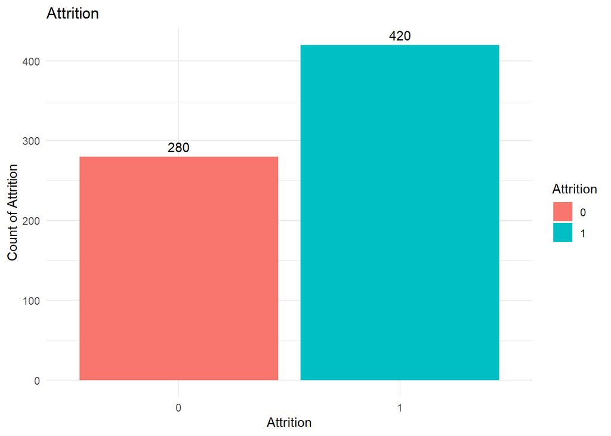

```r
employee4 <- employee3
Classcount = table(employee4$Attrition)
# Over Sampling
over = ( (0.6 * max(Classcount)) - min(Classcount) ) / min(Classcount)
# Under Sampling
under = (0.4 * max(Classcount)) / (min(Classcount) * over)
over = round(over, 1) * 100
under = round(under, 1) * 100
employee4$Attrition = factor(employee4$Attrition)
#Generate the balanced data set
BalancedData = DMwR::SMOTE(Attrition~., employee4, perc.over = over, k = 5, perc.under = under)
# let check the output of the Balancing
BalancedData %>%
        group_by(Attrition) %>%
        tally() %>%
        ggplot(aes(x = Attrition, y = n,fill=Attrition)) +
        geom_bar(stat = "identity") +
        theme_minimal()+
        labs(x="Attrition", y="Count of Attrition")+
        ggtitle("Attrition")+
        geom_text(aes(label = n), vjust = -0.5, position = position_dodge(0.9))
```

```r
## k-NN model for k=2
#Split data into train and test using cross validation in ratio of 70% train and 30% test
set.seed(1)
train <- sample(1:nrow(BalancedData), nrow(BalancedData)*.7)
test = -train
modeldata <- BalancedData[train,]
validationdata <- BalancedData[test,]
cat("Train data has", nrow(modeldata),"observations")
```

```
## Train data has 489 observations
```

```r
cat("Test data has", nrow(validationdata),"observations")
```

```
## Test data has 211 observations
```

```r
# k-NN classifications for full model using all the predictor variables on the balanaced data
classifications = knn(modeldata[,-2], validationdata[,-2], modeldata$Attrition, prob = TRUE, k = 7)
#table(classifications,validationdata$Attrition)
CM = confusionMatrix(table(classifications,validationdata$Attrition))
CM
```

```
## Confusion Matrix and Statistics
##
##
## classifications   0   1
##               0  36  21
##               1  52 102
##
##                Accuracy : 0.654
##                  95% CI : (0.5857, 0.718)
##     No Information Rate : 0.5829
##     P-Value [Acc > NIR] : 0.020707
##
##                   Kappa : 0.2509
##
##  Mcnemar's Test P-Value : 0.000446
##
##             Sensitivity : 0.4091
##             Specificity : 0.8293
##          Pos Pred Value : 0.6316
##          Neg Pred Value : 0.6623
##              Prevalence : 0.4171
##          Detection Rate : 0.1706
##    Detection Prevalence : 0.2701
##       Balanced Accuracy : 0.6192
##
##        'Positive' Class : 0
##
```

### Conclusion for the k-NN model using the balanaced data from SMORE method for classification of employees into Attrition or no Attrition:-

##### To conclude for this k-NN model using balanaced data after SMOTE, the specificty for the model drastically improves, but now the accuracy gets lower.

#### Based on the different models used for this analyis, we will go ahead and use Logistic Regression model, which is the best model so far, for classifying into attrition or no attrition.

### Classifying Attrition for the “Competition Set” for the “CaseStudy2CompSet No Attrition.csv” file using the Logistic Regression model on classification:

##### Logistic Regression model on classification attained more than 60% sensitivity and specificity (60 each = 120 total) for the training and the validation set.

```r
# load "Competition Set" on No Attrition dataset
employeeCompSet = read.csv(file = "C:/Users/seema/Documents/Personal/Study/Data Science at SMU/CaseStudy2CompSet No Attrition.csv", header = TRUE, sep = ",")
dim(employeeCompSet)
```

```
## [1] 300  35
```

```r
head(employeeCompSet,4)
```

```
##     ID Age BusinessTravel DailyRate             Department
## 1 1171  35  Travel_Rarely       750 Research & Development
## 2 1172  33  Travel_Rarely       147        Human Resources
## 3 1173  26  Travel_Rarely      1330 Research & Development
## 4 1174  55  Travel_Rarely      1311 Research & Development
##   DistanceFromHome Education  EducationField EmployeeCount EmployeeNumber
## 1               28         3   Life Sciences             1           1596
## 2                2         3 Human Resources             1           1207
## 3               21         3         Medical             1           1107
## 4                2         3   Life Sciences             1            505
##   EnvironmentSatisfaction Gender HourlyRate JobInvolvement JobLevel
## 1                       2   Male         46              4        2
## 2                       2   Male         99              3        1
## 3                       1   Male         37              3        1
## 4                       3 Female         97              3        4
```

[output cut: 30 more lines]

```r
summary(employeeCompSet)
```

```
##        ID            Age                  BusinessTravel   DailyRate
##  Min.   :1171   Min.   :19.00   Non-Travel       : 32    Min.   : 102.0
##  1st Qu.:1246   1st Qu.:31.00   Travel_Frequently: 57    1st Qu.: 448.0
##  Median :1320   Median :36.00   Travel_Rarely    :211    Median : 775.0
##  Mean   :1320   Mean   :37.86                            Mean   : 784.8
##  3rd Qu.:1395   3rd Qu.:44.00                            3rd Qu.:1117.0
##  Max.   :1470   Max.   :60.00                            Max.   :1490.0
##
##                   Department  DistanceFromHome   Education
##  Human Resources       : 11   Min.   : 1.00    Min.   :1.000
##  Research & Development:209   1st Qu.: 2.00    1st Qu.:2.000
##  Sales                 : 80   Median : 7.00    Median :3.000
##                               Mean   : 9.26    Mean   :2.973
##                               3rd Qu.:14.00    3rd Qu.:4.000
##                               Max.   :29.00    Max.   :5.000
##
##           EducationField EmployeeCount EmployeeNumber
##  Human Resources :  7    Min.   :1     Min.   :   2.0
##  Life Sciences   :130    1st Qu.:1     1st Qu.: 508.8
##  Marketing       : 27    Median :1     Median : 994.5
##  Medical         : 94    Mean   :1     Mean   :1020.9
##  Other           : 12    3rd Qu.:1     3rd Qu.:1542.5
##  Technical Degree: 30    Max.   :1     Max.   :2065.0
##
##  EnvironmentSatisfaction    Gender      HourlyRate     JobInvolvement
##  Min.   :1.000           Female:105   Min.   : 30.00   Min.   :1.000
##  1st Qu.:2.000           Male  :195   1st Qu.: 50.00   1st Qu.:2.000
##  Median :3.000                        Median : 66.00   Median :3.000
##  Mean   :2.733                        Mean   : 66.07   Mean   :2.743
##  3rd Qu.:4.000                        3rd Qu.: 83.00   3rd Qu.:3.000
##  Max.   :4.000                        Max.   :100.00   Max.   :4.000
##
##     JobLevel                        JobRole   JobSatisfaction
##  Min.   :1.0   Research Scientist       :61   Min.   :1.000
##  1st Qu.:1.0   Sales Executive          :57   1st Qu.:2.000
##  Median :2.0   Laboratory Technician    :55   Median :3.000
##  Mean   :2.2   Manufacturing Director   :31   Mean   :2.767
##  3rd Qu.:3.0   Manager                  :30   3rd Qu.:4.000
##  Max.   :5.0   Healthcare Representative:29   Max.   :4.000
##                (Other)                  :37
```

[output cut: 25 more lines]

```
##  Min.   :1.000   Min.   : 0.000   Min.   : 0.00
##  1st Qu.:2.000   1st Qu.: 3.000   1st Qu.: 2.00
##  Median :3.000   Median : 5.000   Median : 3.00
##  Mean   :2.747   Mean   : 7.527   Mean   : 4.33
##  3rd Qu.:3.000   3rd Qu.:10.000   3rd Qu.: 7.00
##  Max.   :4.000   Max.   :37.000   Max.   :18.00
##
##  YearsSinceLastPromotion YearsWithCurrManager
##  Min.   : 0.00           Min.   : 0.00
##  1st Qu.: 0.00           1st Qu.: 2.00
##  Median : 1.00           Median : 3.00
##  Mean   : 2.29           Mean   : 4.38
##  3rd Qu.: 3.00           3rd Qu.: 7.00
##  Max.   :15.00           Max.   :17.00
##
```

```r
#check for NA values
table(is.na(employeeCompSet))
```

```
##
## FALSE
## 10500
```

```r
#Checking the missing value
sapply(employeeCompSet, function(x) sum(is.na(x)))
```

```
##                       ID                      Age           BusinessTravel
##                        0                        0                        0
##                DailyRate               Department         DistanceFromHome
##                        0                        0                        0
##                Education           EducationField            EmployeeCount
##                        0                        0                        0
##           EmployeeNumber  EnvironmentSatisfaction                   Gender
##                        0                        0                        0
##               HourlyRate           JobInvolvement                 JobLevel
##                        0                        0                        0
##                  JobRole          JobSatisfaction            MaritalStatus
##                        0                        0                        0
##            MonthlyIncome              MonthlyRate       NumCompaniesWorked
##                        0                        0                        0
##                   Over18                 OverTime        PercentSalaryHike
##                        0                        0                        0
##        PerformanceRating RelationshipSatisfaction            StandardHours
##                        0                        0                        0
##         StockOptionLevel        TotalWorkingYears    TrainingTimesLastYear
##                        0                        0                        0
##          WorkLifeBalance           YearsAtCompany       YearsInCurrentRole
##                        0                        0                        0
##  YearsSinceLastPromotion     YearsWithCurrManager
##                        0                        0
```

```r
#check for duplicated values
sum(duplicated(employeeCompSet))
```

```
## [1] 0
```

```r
#see data frame dimensions and column data types
#str(employeeCompSet)

# remove some variable whose value is not changing. So standard deviation of that variable is zero. So it is not Significant for analysis. Those variable are ID, Employee Count, Employee Number, Over18, StandardHours
employeeCompSetReduceCols <- employeeCompSet[, -c(1,9,10,22,27)]

employeeCompSet2 <- employeeCompSetReduceCols
# Changing the class of variable from numeric to factor
employeeCompSet2$Education <- factor(employeeCompSet2$Education)
employeeCompSet2$EnvironmentSatisfaction <- factor(employeeCompSet2$EnvironmentSatisfaction)
employeeCompSet2$JobInvolvement <- factor(employeeCompSet2$JobInvolvement)
employeeCompSet2$JobLevel <- factor(employeeCompSet2$JobLevel)
employeeCompSet2$JobSatisfaction <- factor(employeeCompSet2$JobSatisfaction)
employeeCompSet2$PerformanceRating <- factor(employeeCompSet2$PerformanceRating)
employeeCompSet2$RelationshipSatisfaction <- factor(employeeCompSet2$RelationshipSatisfaction)
employeeCompSet2$StockOptionLevel <- factor(employeeCompSet2$StockOptionLevel)
employeeCompSet2$WorkLifeBalance <- factor(employeeCompSet2$WorkLifeBalance)

# Changing the categorical variables to dummy variable so that the variables can be used for fit in the classification model
dmy <- dummyVars(" ~ .", data = employeeCompSet2, fullRank=T)
employeeCompSet3 <- data.frame(predict(dmy, newdata = employeeCompSet2))
print(str(employeeCompSet3))
```

```
## 'data.frame':    300 obs. of  62 variables:
##  $ Age                              : num  35 33 26 55 29 51 52 39 31 31 ...
##  $ BusinessTravel.Travel_Frequently : num  0 0 0 0 0 1 0 0 0 1 ...
##  $ BusinessTravel.Travel_Rarely     : num  1 1 1 1 1 0 0 1 1 0 ...
##  $ DailyRate                        : num  750 147 1330 1311 1246 ...
##  $ Department.Research...Development: num  1 0 1 1 0 1 0 1 1 1 ...
##  $ Department.Sales                 : num  0 0 0 0 1 0 1 0 0 0 ...
##  $ DistanceFromHome                 : num  28 2 21 2 19 1 29 10 24 20 ...
##  $ Education.2                      : num  0 0 0 0 0 0 0 0 0 0 ...
##  $ Education.3                      : num  1 1 1 1 1 0 0 0 1 1 ...
##  $ Education.4                      : num  0 0 0 0 0 1 1 0 0 0 ...
##  $ Education.5                      : num  0 0 0 0 0 0 0 1 0 0 ...
##  $ EducationField.Life.Sciences     : num  1 0 0 1 1 0 1 0 0 1 ...
##  $ EducationField.Marketing         : num  0 0 0 0 0 0 0 0 0 0 ...
##  $ EducationField.Medical           : num  0 0 1 0 0 1 0 1 1 0 ...
```

[output cut: 49 more lines]

```r
validationdata2 <- employeeCompSet3

# Accessing the predictive ability of the logistic regression model
log_pred <- predict(logmodel,newdata=validationdata2,type='response')
log_pred <- ifelse(log_pred>=0.5,1,0)
# merge predicted variable to the CompSet file
mergedataemployeeCompSet <- merge(employeeCompSet$ID, log_pred, by=0, all=TRUE)
#dim(mergedataemployeeCompSet)
#head(mergedataemployeeCompSet,2)

mergedataemployeeCompSet$y <- ifelse(mergedataemployeeCompSet$y == 1,"Yes","No")
colnames(mergedataemployeeCompSet)[colnames(mergedataemployeeCompSet)=="Row.names"] <- "RowNumber"
colnames(mergedataemployeeCompSet)[colnames(mergedataemployeeCompSet)=="x"] <- "ID"
colnames(mergedataemployeeCompSet)[colnames(mergedataemployeeCompSet)=="y"] <- "Attrition"
classifyemployeeCompSet <- mergedataemployeeCompSet[order(mergedataemployeeCompSet$ID),] %>% dplyr::select(ID, Attrition)
#dim(classifyemployeeCompSet)
# write to csv file for classifying dataset for the "Competition Set" on Attrition
write.csv(classifyemployeeCompSet, file = "Case2PredictionsSrivastava Attrition.csv", row.names=FALSE)
```

### Predicting Monthly Incomes for the “CaseStudy2CompSet No Salary.csv” file using the Linear Regression model:

##### Linear Regression model on prediting the monthly income attained a RMSE < $3000 for the training and the validation set.

```r
## Linear Regression model

#Split data into train and test using cross validation in ratio of 70% train and 30% test
set.seed(2017)
train <- sample(1:nrow(employee3), nrow(employee3)*.7)
test = -train
modeldata <- employee3[train,]
validationdata <- employee3[test,]
cat("Train data has", nrow(modeldata),"observations")
```

```
## Train data has 609 observations
```

```r
cat("Test data has", nrow(validationdata),"observations")
```

```
## Test data has 261 observations
```

```r
# Fit the Linear Regression model for predicting monthly incomes (salaries)
Model1_fit = lm(MonthlyIncome~., data = modeldata)
summary(Model1_fit)
```

```
##
## Call:
## lm(formula = MonthlyIncome ~ ., data = modeldata)
##
## Residuals:
##     Min      1Q  Median      3Q     Max
## -3157.3  -567.3   -44.7   543.7  4409.8
##
## Coefficients:
##                                     Estimate Std. Error t value Pr(>|t|)
## (Intercept)                        2.525e+03  8.369e+02   3.017 0.002673
## Age                                1.225e+00  6.650e+00   0.184 0.853938
## Attrition                         -1.355e+02  1.347e+02  -1.006 0.314948
## BusinessTravel.Travel_Frequently   3.117e+02  1.629e+02   1.914 0.056188
## BusinessTravel.Travel_Rarely       4.563e+02  1.383e+02   3.298 0.001036
## DailyRate                          1.888e-01  1.056e-01   1.788 0.074307
## Department.Research...Development  2.565e+02  6.071e+02   0.423 0.672811
## Department.Sales                  -2.744e+02  6.359e+02  -0.432 0.666273
## DistanceFromHome                  -7.556e+00  5.286e+00  -1.429 0.153482
## Education.2                       -9.050e+01  1.540e+02  -0.588 0.557002
## Education.3                       -1.947e+02  1.386e+02  -1.405 0.160547
## Education.4                        1.564e+01  1.498e+02   0.104 0.916910
## Education.5                       -6.566e+02  2.844e+02  -2.309 0.021335
## EducationField.Life.Sciences       1.041e+02  4.304e+02   0.242 0.809052
## EducationField.Marketing           1.798e+02  4.550e+02   0.395 0.692777
## EducationField.Medical             8.460e+01  4.318e+02   0.196 0.844740
## EducationField.Other               5.163e+01  4.584e+02   0.113 0.910364
## EducationField.Technical.Degree    1.651e+02  4.526e+02   0.365 0.715444
## EnvironmentSatisfaction.2         -2.565e+01  1.309e+02  -0.196 0.844695
## EnvironmentSatisfaction.3         -1.021e+02  1.208e+02  -0.846 0.398052
## EnvironmentSatisfaction.4         -1.028e+02  1.224e+02  -0.840 0.401000
## Gender.Male                        1.377e+02  8.511e+01   1.617 0.106367
## HourlyRate                         5.521e-01  2.062e+00   0.268 0.789005
## JobInvolvement.2                  -1.197e+02  1.850e+02  -0.647 0.517712
## JobInvolvement.3                  -2.117e+02  1.765e+02  -1.199 0.230969
## JobInvolvement.4                   1.143e+01  2.140e+02   0.053 0.957437
## JobLevel.2                         1.798e+03  1.830e+02   9.823  < 2e-16
## JobLevel.3                         5.089e+03  2.327e+02  21.868  < 2e-16
## JobLevel.4                         8.536e+03  3.431e+02  24.876  < 2e-16
## JobLevel.5                         1.111e+04  4.098e+02  27.109  < 2e-16
```

[output cut: 88 more lines]

```
## TotalWorkingYears                 ***
## TrainingTimesLastYear
## WorkLifeBalance.2
## WorkLifeBalance.3
## WorkLifeBalance.4
## YearsAtCompany
## YearsInCurrentRole
## YearsSinceLastPromotion
## YearsWithCurrManager
## ---
## Signif. codes:  0 '***' 0.001 '**' 0.01 '*' 0.05 '.' 0.1 ' ' 1
##
## Residual standard error: 986.9 on 546 degrees of freedom
## Multiple R-squared:  0.9584, Adjusted R-squared:  0.9536
## F-statistic: 202.7 on 62 and 546 DF,  p-value: < 2.2e-16
```

```r
#confint(Model1_fit)

Model1_Preds = predict(Model1_fit, newdata = validationdata)
#Accuracy Statistics for the Linear Regression model
#MSE for the Linear Regression model
MSE = mean((validationdata$MonthlyIncome - Model1_Preds)^2)
MSE
```

```
## [1] 1200291
```

```r
#RMSE (Root Mean square error) for the Linear Regression model
RMSE = sqrt(MSE)
RMSE
```

```
## [1] 1095.578
```

```r
# load "Competition Set" on No Monthly Incomes dataset having no Salary
MonthlyIncomeCompSet = read.csv(file = "C:/Users/seema/Documents/Personal/Study/Data Science at SMU/CaseStudy2CompSetNoSalary.csv", header = TRUE, sep = ",")
dim(MonthlyIncomeCompSet)
```

```
## [1] 300  35
```

```r
head(MonthlyIncomeCompSet,4)
```

```
##    ID Age Attrition    BusinessTravel DailyRate             Department
## 1 871  43        No Travel_Frequently      1422                  Sales
## 2 872  33        No     Travel_Rarely       461 Research & Development
## 3 873  55       Yes     Travel_Rarely       267                  Sales
## 4 874  36        No        Non-Travel      1351 Research & Development
##   DistanceFromHome Education EducationField EmployeeCount EmployeeNumber
## 1                2         4  Life Sciences             1           1849
## 2               13         1  Life Sciences             1            995
## 3               13         4      Marketing             1           1372
## 4                9         4  Life Sciences             1           1949
##   EnvironmentSatisfaction Gender HourlyRate JobInvolvement JobLevel
## 1                       1   Male         92              3        2
## 2                       2 Female         53              3        1
## 3                       1   Male         85              4        4
## 4                       1   Male         66              4        1
```

[output cut: 25 more lines]

```r
summary(MonthlyIncomeCompSet)
```

```
##        ID              Age        Attrition           BusinessTravel
##  Min.   : 871.0   Min.   :18.00   No :249   Non-Travel       : 24
##  1st Qu.: 945.8   1st Qu.:29.00   Yes: 51   Travel_Frequently: 62
##  Median :1020.5   Median :36.00             Travel_Rarely    :214
##  Mean   :1020.5   Mean   :36.27
##  3rd Qu.:1095.2   3rd Qu.:42.00
##  Max.   :1170.0   Max.   :60.00
##
##    DailyRate                       Department  DistanceFromHome
##  Min.   : 105.0   Human Resources       : 17   Min.   : 1.00
##  1st Qu.: 429.2   Research & Development:190   1st Qu.: 2.00
##  Median : 693.0   Sales                 : 93   Median : 7.00
##  Mean   : 783.2                                Mean   : 8.70
##  3rd Qu.:1171.2                                3rd Qu.:11.25
##  Max.   :1492.0                                Max.   :29.00
##
##    Education              EducationField EmployeeCount EmployeeNumber
##  Min.   :1.000   Human Resources :  5    Min.   :1     Min.   :   7
##  1st Qu.:2.000   Life Sciences   :118    1st Qu.:1     1st Qu.: 477
##  Median :3.000   Marketing       : 32    Median :1     Median :1008
##  Mean   :2.887   Medical         :100    Mean   :1     Mean   :1014
##  3rd Qu.:4.000   Other           : 18    3rd Qu.:1     3rd Qu.:1569
##  Max.   :5.000   Technical Degree: 27    Max.   :1     Max.   :2068
##
##  EnvironmentSatisfaction    Gender      HourlyRate     JobInvolvement
##  Min.   :1.00            Female:129   Min.   : 30.00   Min.   :1.000
##  1st Qu.:2.00            Male  :171   1st Qu.: 48.00   1st Qu.:2.000
##  Median :3.00                         Median : 66.00   Median :3.000
##  Mean   :2.77                         Mean   : 66.52   Mean   :2.737
##  3rd Qu.:4.00                         3rd Qu.: 85.25   3rd Qu.:3.000
##  Max.   :4.00                         Max.   :100.00   Max.   :4.000
##
##     JobLevel                      JobRole   JobSatisfaction  MaritalStatus
##  Min.   :1   Sales Executive          :69   Min.   :1.000   Divorced: 71
##  1st Qu.:1   Research Scientist       :59   1st Qu.:2.000   Married :135
##  Median :2   Laboratory Technician    :51   Median :3.000   Single  : 94
##  Mean   :2   Manufacturing Director   :27   Mean   :2.747
##  3rd Qu.:2   Healthcare Representative:26   3rd Qu.:4.000
##  Max.   :5   Manager                  :21   Max.   :4.000
##              (Other)                  :47
```

[output cut: 17 more lines]

```
##  Min.   : 0.00     Min.   :0.00          Min.   :1.000   Min.   : 0.000
##  1st Qu.: 6.00     1st Qu.:2.00          1st Qu.:2.000   1st Qu.: 3.000
##  Median : 9.00     Median :3.00          Median :3.000   Median : 5.000
##  Mean   :10.78     Mean   :2.82          Mean   :2.717   Mean   : 6.623
##  3rd Qu.:14.00     3rd Qu.:3.00          3rd Qu.:3.000   3rd Qu.: 9.000
##  Max.   :40.00     Max.   :6.00          Max.   :4.000   Max.   :33.000
##
##  YearsInCurrentRole YearsSinceLastPromotion YearsWithCurrManager
##  Min.   : 0.0       Min.   : 0.00           Min.   : 0.000
##  1st Qu.: 2.0       1st Qu.: 0.00           1st Qu.: 2.000
##  Median : 3.0       Median : 1.00           Median : 3.000
##  Mean   : 4.2       Mean   : 2.14           Mean   : 3.817
##  3rd Qu.: 7.0       3rd Qu.: 3.00           3rd Qu.: 7.000
##  Max.   :16.0       Max.   :15.00           Max.   :15.000
##
```

```r
#check for NA values
table(is.na(MonthlyIncomeCompSet))
```

```
##
## FALSE
## 10500
```

```r
#Checking the missing value
sapply(MonthlyIncomeCompSet, function(x) sum(is.na(x)))
```

```
##                       ID                      Age                Attrition
##                        0                        0                        0
##           BusinessTravel                DailyRate               Department
##                        0                        0                        0
##         DistanceFromHome                Education           EducationField
##                        0                        0                        0
##            EmployeeCount           EmployeeNumber  EnvironmentSatisfaction
##                        0                        0                        0
##                   Gender               HourlyRate           JobInvolvement
##                        0                        0                        0
##                 JobLevel                  JobRole          JobSatisfaction
##                        0                        0                        0
##            MaritalStatus              MonthlyRate       NumCompaniesWorked
##                        0                        0                        0
##                   Over18                 OverTime        PercentSalaryHike
##                        0                        0                        0
##        PerformanceRating RelationshipSatisfaction            StandardHours
##                        0                        0                        0
##         StockOptionLevel        TotalWorkingYears    TrainingTimesLastYear
##                        0                        0                        0
##          WorkLifeBalance           YearsAtCompany       YearsInCurrentRole
##                        0                        0                        0
##  YearsSinceLastPromotion     YearsWithCurrManager
##                        0                        0
```

```r
#check for duplicated values
sum(duplicated(MonthlyIncomeCompSet))
```

```
## [1] 0
```

```r
#see data frame dimensions and column data types
#str(employeeCompSet)

# remove some variable whose value is not changing. So standard deviation of that variable is zero. So it is not Significant for analysis. Those variable are ID, Employee Count, Employee Number, Over18, StandardHours
MonthlyIncomeCompSetReduceCols <- MonthlyIncomeCompSet[, -c(1,10,11,22,27)]

MonthlyIncomeCompSet2 <- MonthlyIncomeCompSetReduceCols
# Changing the class of variable from numeric to factor
MonthlyIncomeCompSet2$Education <- factor(MonthlyIncomeCompSet2$Education)
MonthlyIncomeCompSet2$EnvironmentSatisfaction <- factor(MonthlyIncomeCompSet2$EnvironmentSatisfaction)
MonthlyIncomeCompSet2$JobInvolvement <- factor(MonthlyIncomeCompSet2$JobInvolvement)
MonthlyIncomeCompSet2$JobLevel <- factor(MonthlyIncomeCompSet2$JobLevel)
MonthlyIncomeCompSet2$JobSatisfaction <- factor(MonthlyIncomeCompSet2$JobSatisfaction)
MonthlyIncomeCompSet2$PerformanceRating <- factor(MonthlyIncomeCompSet2$PerformanceRating)
MonthlyIncomeCompSet2$RelationshipSatisfaction <- factor(MonthlyIncomeCompSet2$RelationshipSatisfaction)
MonthlyIncomeCompSet2$StockOptionLevel <- factor(MonthlyIncomeCompSet2$StockOptionLevel)
MonthlyIncomeCompSet2$WorkLifeBalance <- factor(MonthlyIncomeCompSet2$WorkLifeBalance)
# Changing the Atrition variable value to 1 for 'Yes' and 0 for 'No'
MonthlyIncomeCompSet2$Attrition <- ifelse(MonthlyIncomeCompSet2$Attrition == "Yes",1,0)

# Changing the categorical variables to dummy variable so that the variables can be used for fit in the prediction model
dmy <- dummyVars(" ~ .", data = MonthlyIncomeCompSet2, fullRank=T)
MonthlyIncomeCompSet3 <- data.frame(predict(dmy, newdata = MonthlyIncomeCompSet2))
print(str(MonthlyIncomeCompSet3))
```

```
## 'data.frame':    300 obs. of  62 variables:
##  $ Age                              : num  43 33 55 36 27 39 33 21 30 51 ...
##  $ Attrition                        : num  0 0 1 0 0 1 0 1 0 0 ...
##  $ BusinessTravel.Travel_Frequently : num  1 0 0 0 0 0 0 1 1 0 ...
##  $ BusinessTravel.Travel_Rarely     : num  0 1 1 0 1 1 0 0 0 1 ...
##  $ DailyRate                        : num  1422 461 267 1351 1302 ...
##  $ Department.Research...Development: num  0 1 0 1 1 0 0 1 1 1 ...
##  $ Department.Sales                 : num  1 0 1 0 0 1 1 0 0 0 ...
##  $ DistanceFromHome                 : num  2 13 13 9 19 5 22 10 23 11 ...
##  $ Education.2                      : num  0 0 0 0 0 0 1 1 0 1 ...
##  $ Education.3                      : num  0 0 0 0 1 1 0 0 1 0 ...
##  $ Education.4                      : num  1 0 1 1 0 0 0 0 0 0 ...
##  $ Education.5                      : num  0 0 0 0 0 0 0 0 0 0 ...
##  $ EducationField.Life.Sciences     : num  1 1 0 1 0 0 0 1 1 0 ...
##  $ EducationField.Marketing         : num  0 0 1 0 0 0 1 0 0 0 ...
```

[output cut: 49 more lines]

```r
validationdata2 <- MonthlyIncomeCompSet3

# Accessing the predictive ability of the Linear Regression model on the CompSet dataset
MonthlyIncomeCompSet_preds <- predict(Model1_fit, newdata = validationdata2)
# merge predicted Monthly Income variable to the CompSet file
mergedataMonthlyIncomeCompSet <- merge(MonthlyIncomeCompSet$ID, MonthlyIncomeCompSet_preds, by=0, all=TRUE)
#dim(mergedataMonthlyIncomeCompSet)
#head(mergedataMonthlyIncomeCompSet,2)
# renaming the merged variable names
colnames(mergedataMonthlyIncomeCompSet)[colnames(mergedataMonthlyIncomeCompSet)=="Row.names"] <- "RowNumber"
colnames(mergedataMonthlyIncomeCompSet)[colnames(mergedataMonthlyIncomeCompSet)=="x"] <- "ID"
colnames(mergedataMonthlyIncomeCompSet)[colnames(mergedataMonthlyIncomeCompSet)=="y"] <- "MonthlyIncome"
predictMonthlyIncomeCompSet <- mergedataMonthlyIncomeCompSet[order(mergedataMonthlyIncomeCompSet$ID),] %>% dplyr::select(ID, MonthlyIncome)
#dim(predictMonthlyIncomeCompSet)
#head(predictMonthlyIncomeCompSet,2)
# write to csv file for predicting dataset for the "Competition Set" on Monthly Income
write.csv(predictMonthlyIncomeCompSet, file = "Case2PredictionsSrivastava Salary.csv", row.names=FALSE)
```